# Central Limit Theorem

Module 5 A1 Week 5

Load the required packages.

```r
library(tidyverse)
library(statsr)
```

### Question 1

Load a data set `nc` which contain information on births recorded in the state of North Carolina. Plot the histograms for the variables `weight`, `premie` and `weeks`

```
Rows: 1,000
Columns: 13
$ fage           <int> NA, NA, 19, 21, NA, NA, 18, 17, NA, 20, 30, NA, NA, NA…
$ mage           <int> 13, 14, 15, 15, 15, 15, 15, 15, 16, 16, 16, 16, 16, 16…
$ mature         <fct> younger mom, younger mom, younger mom, younger mom, yo…
$ weeks          <int> 39, 42, 37, 41, 39, 38, 37, 35, 38, 37, 45, 42, 40, 38…
$ premie         <fct> full term, full term, full term, full term, full term,…
$ visits         <int> 10, 15, 11, 6, 9, 19, 12, 5, 9, 13, 9, 8, 4, 12, 15, 7…
$ marital        <fct> married, married, married, married, married, married, …
$ gained         <int> 38, 20, 38, 34, 27, 22, 76, 15, NA, 52, 28, 34, 12, 30…
$ weight         <dbl> 7.63, 7.88, 6.63, 8.00, 6.38, 5.38, 8.44, 4.69, 8.81, …
$ lowbirthweight <fct> not low, not low, not low, not low, not low, low, not …
$ gender         <fct> male, male, female, male, female, male, male, male, ma…
$ habit          <fct> nonsmoker, nonsmoker, nonsmoker, nonsmoker, nonsmoker,…
$ whitemom       <fct> not white, not white, white, white, not white, not whi…
```

```
[1] full term premie    <NA>
Levels: full term premie
```

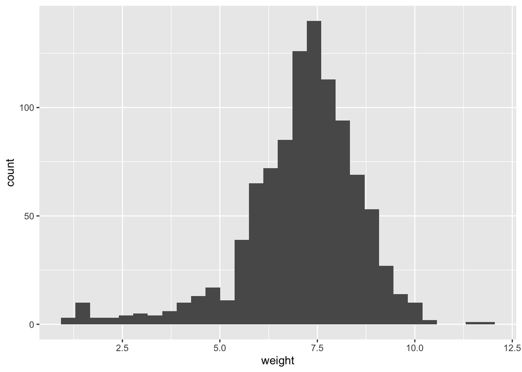

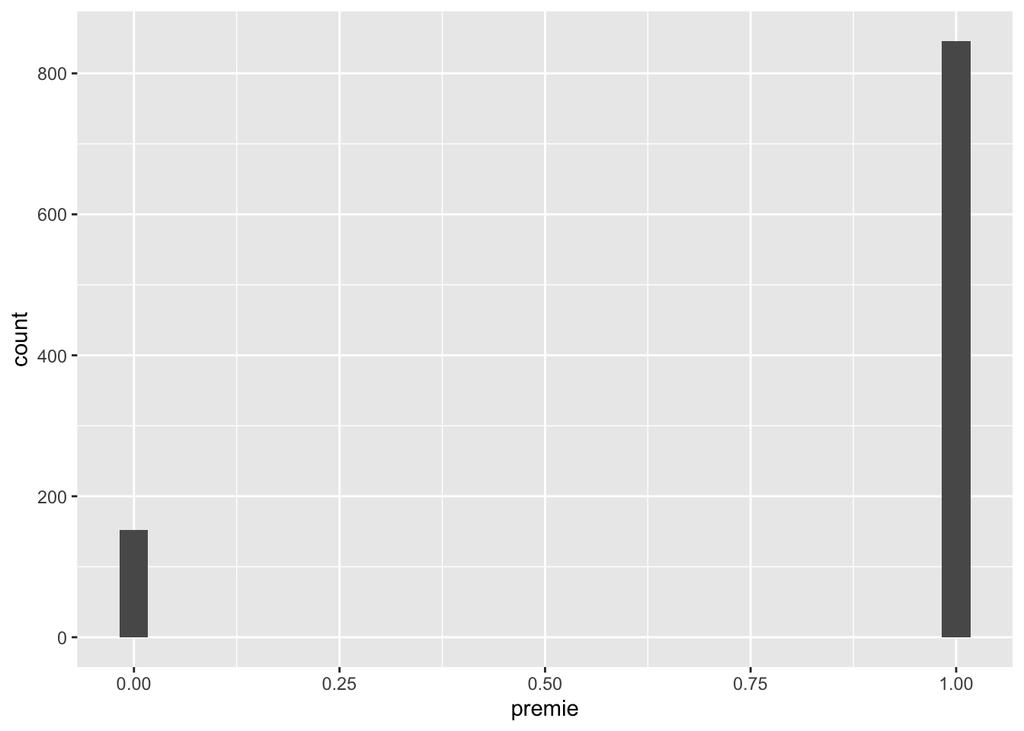

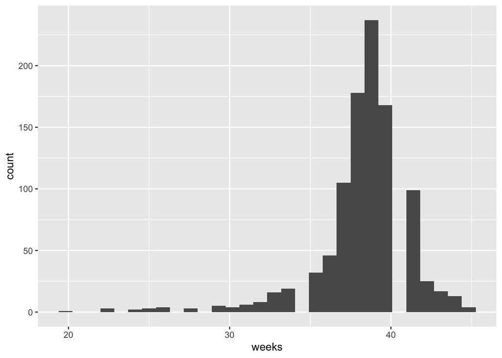

**Comment on the distribution of the histograms.**

### Question 2

Let us take into consideration the variable `weight`. Take repeated sample (5000 samples) of size 5,25,100 and find the average `weight` for each sample. Thus write a for-loop to sample $\bar{x}$ for n = 5, 25, 100 where $\bar{x}$ is the average weight.

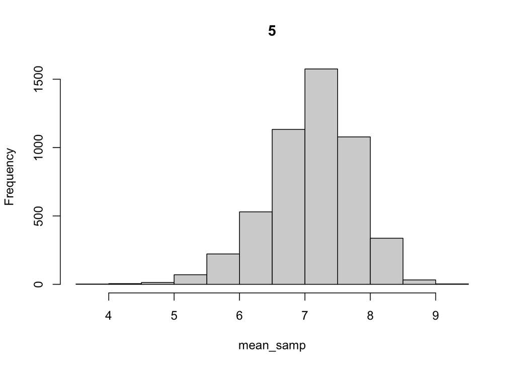

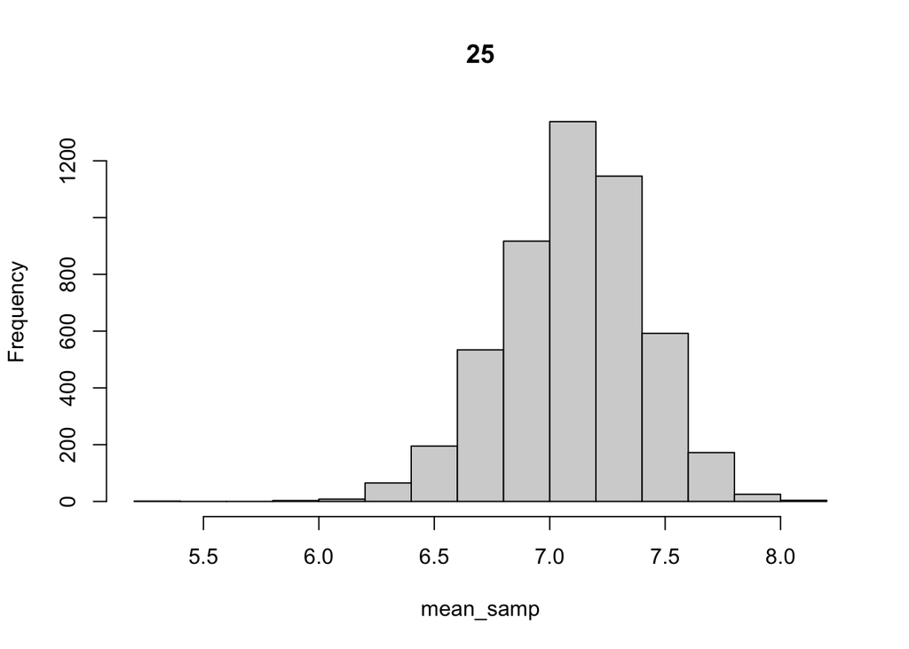

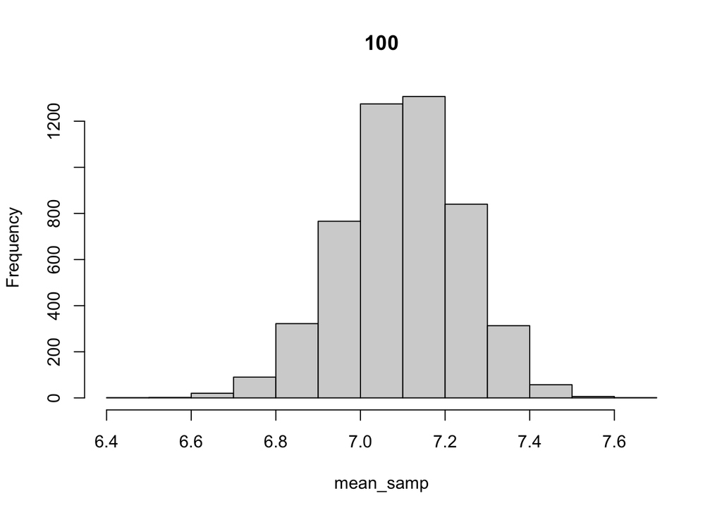

### Question 3

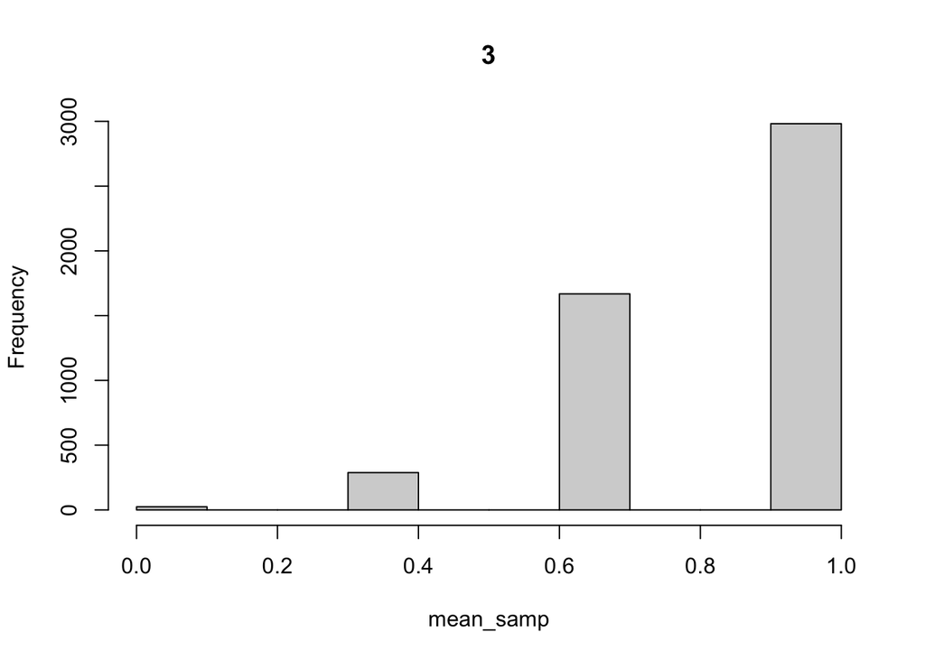

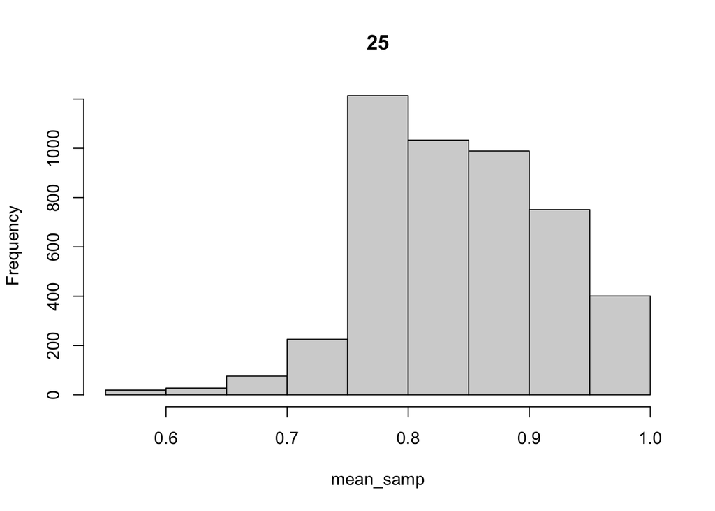

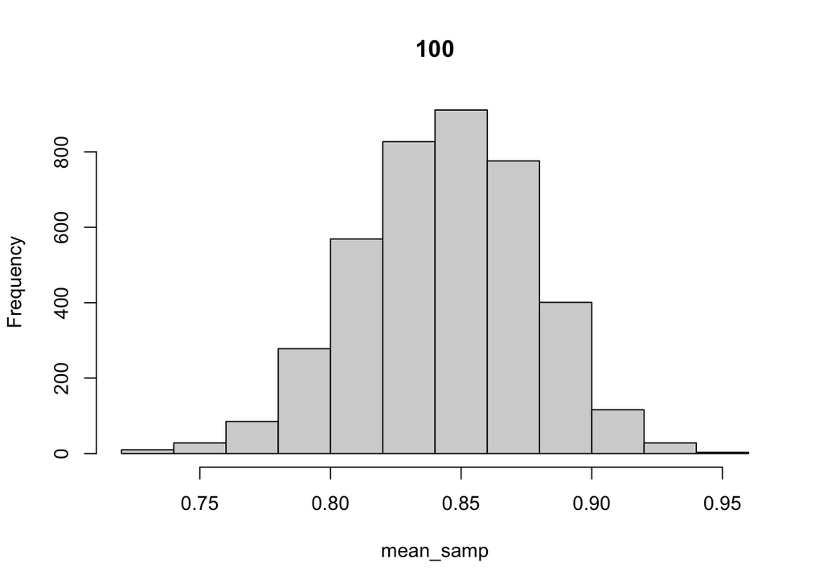

### Question 4

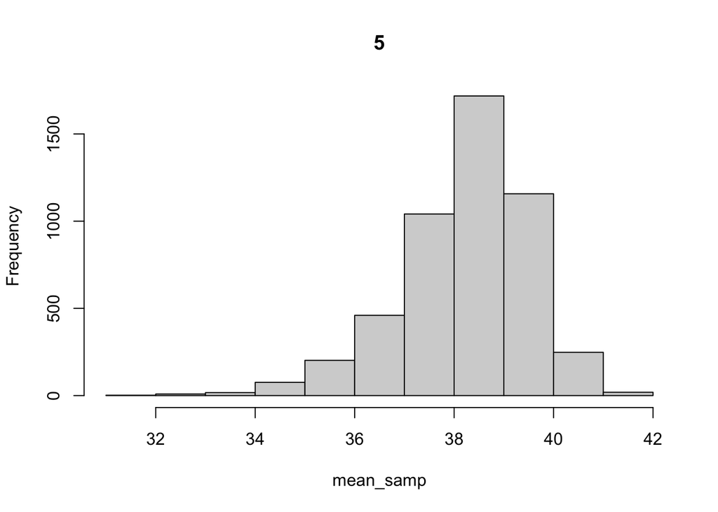

### Question 5

Plot the histograms for Questions 2-4.

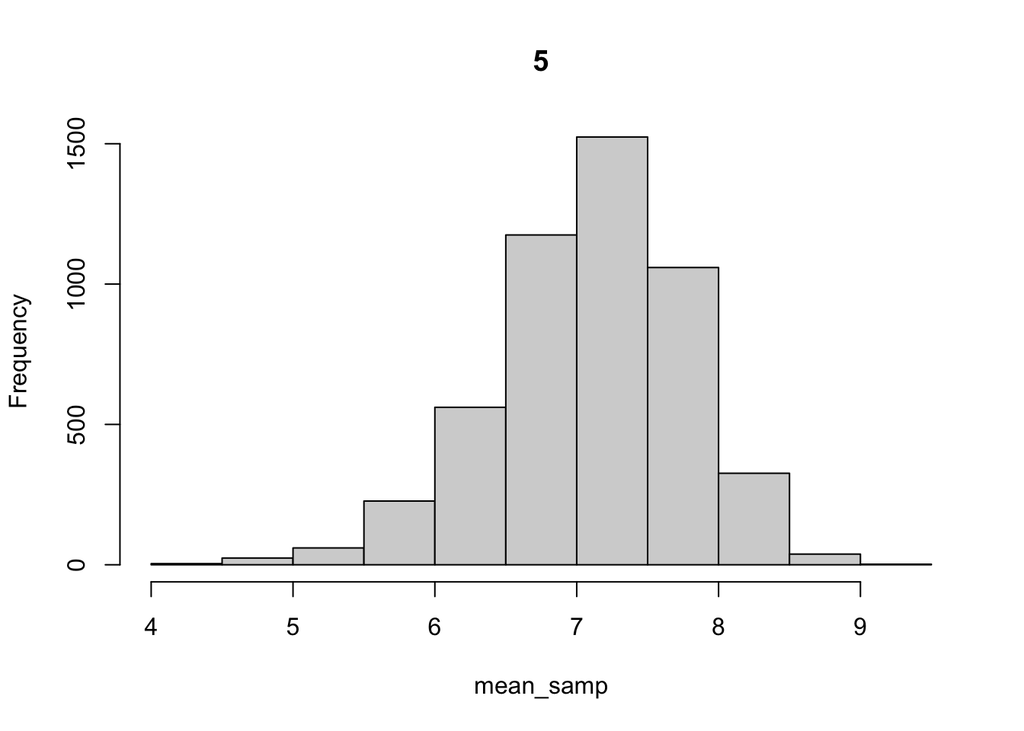

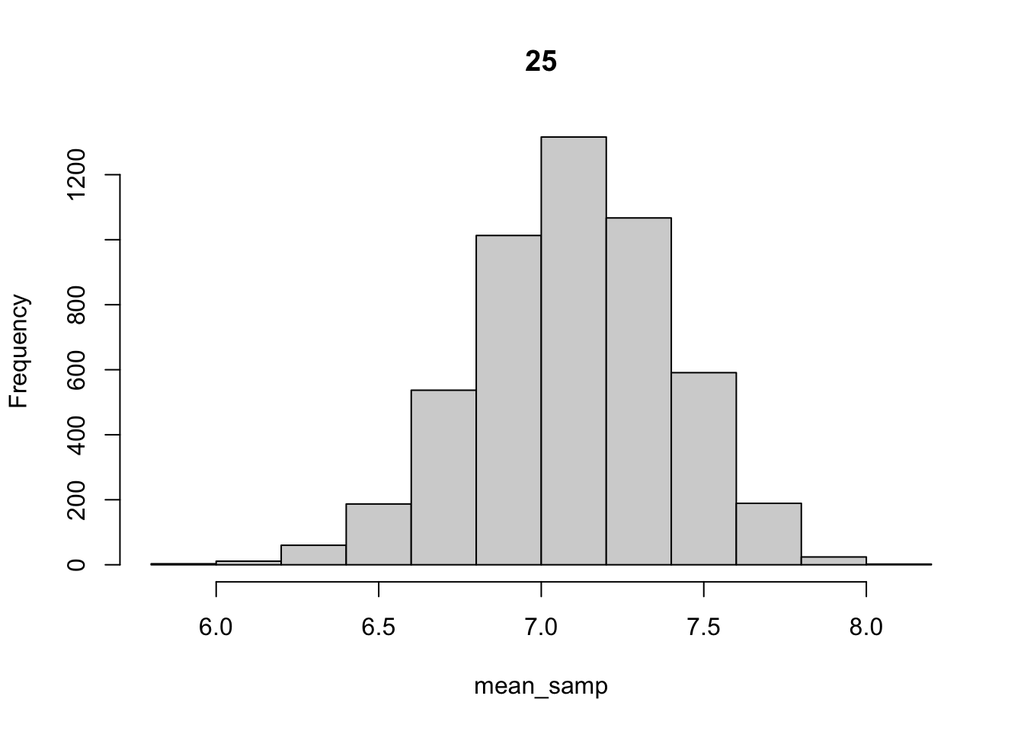

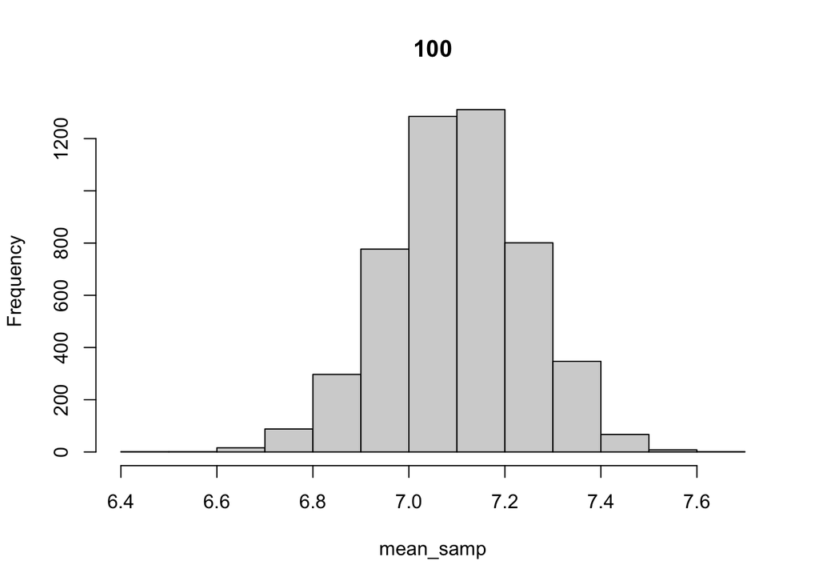

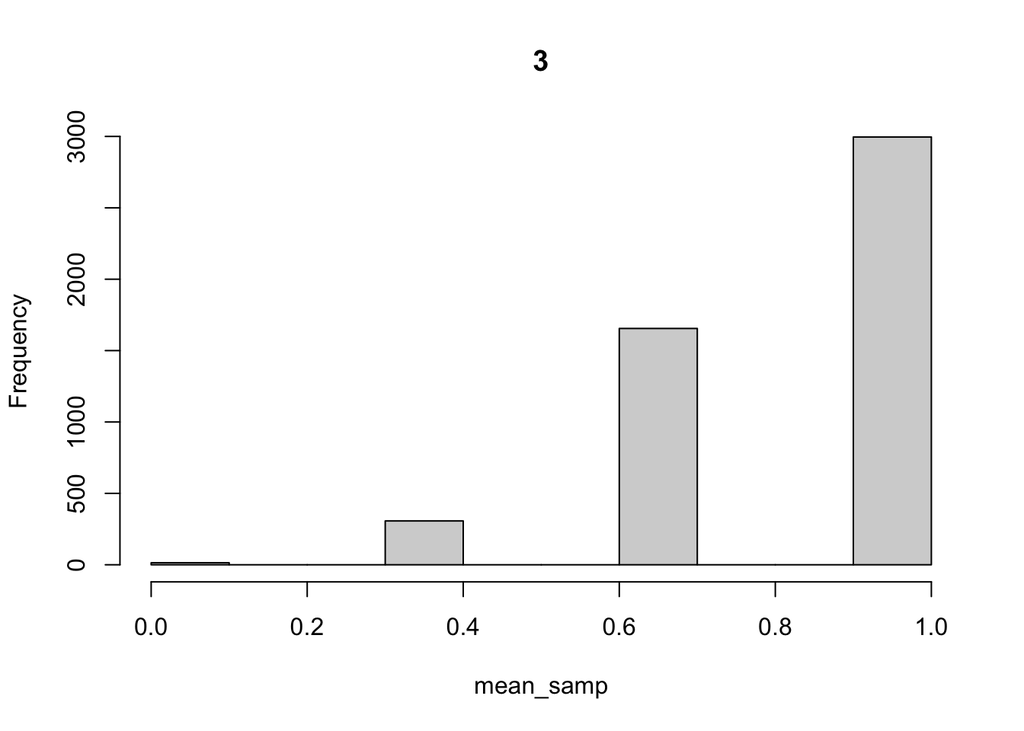

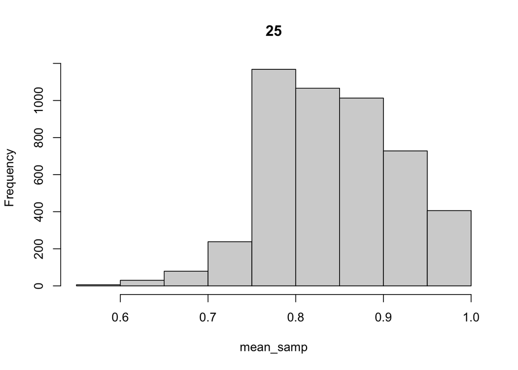

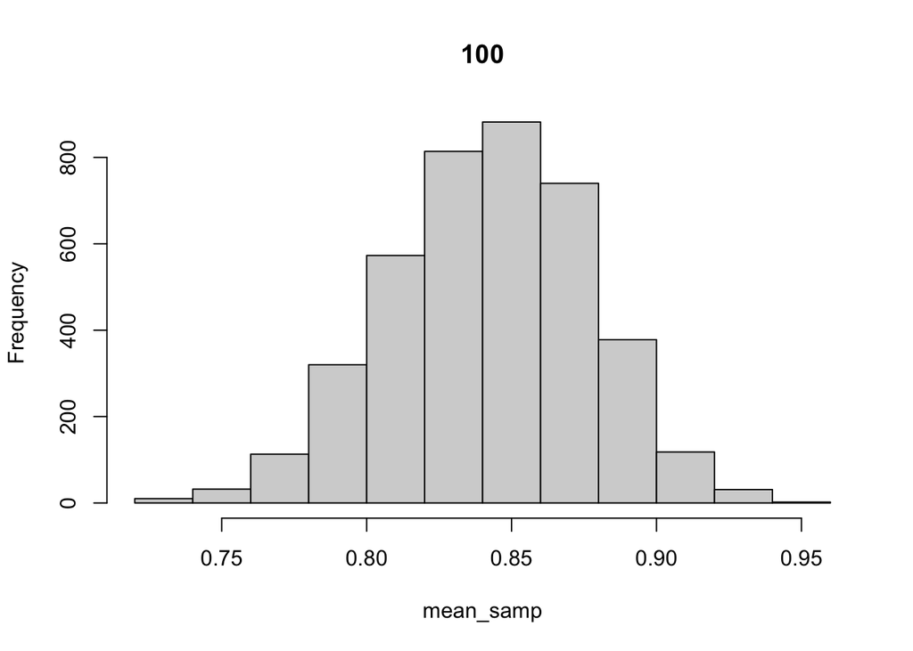

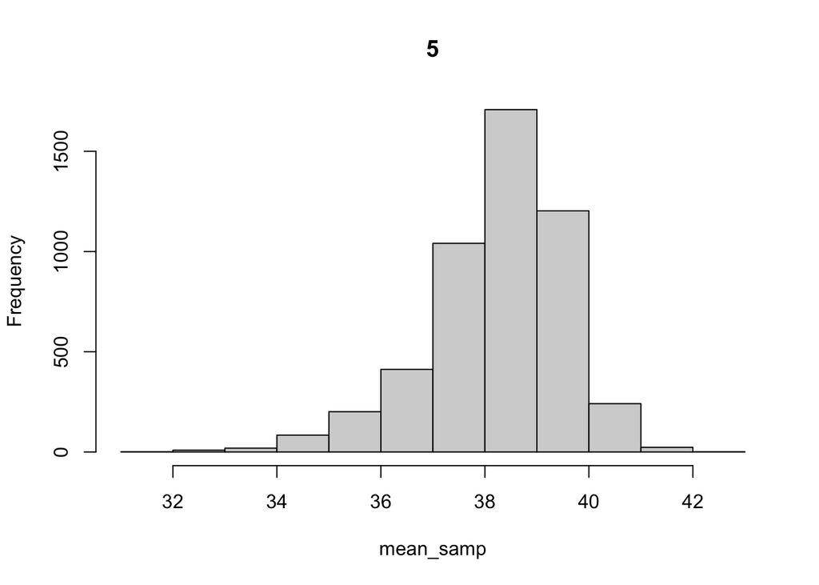

### Question 6

Comment on the similarities or disimilarities of the histograms. (1-3 sentences)

```r
#All of the histograms with high n value are relatively guassian, while those with low n are always skewed.
```

### Question 7

```
If you alter the for-loop in Question 4 to sample n= 50 rather than n = 5, does the updated histogram better match those from 2 & 3?
```

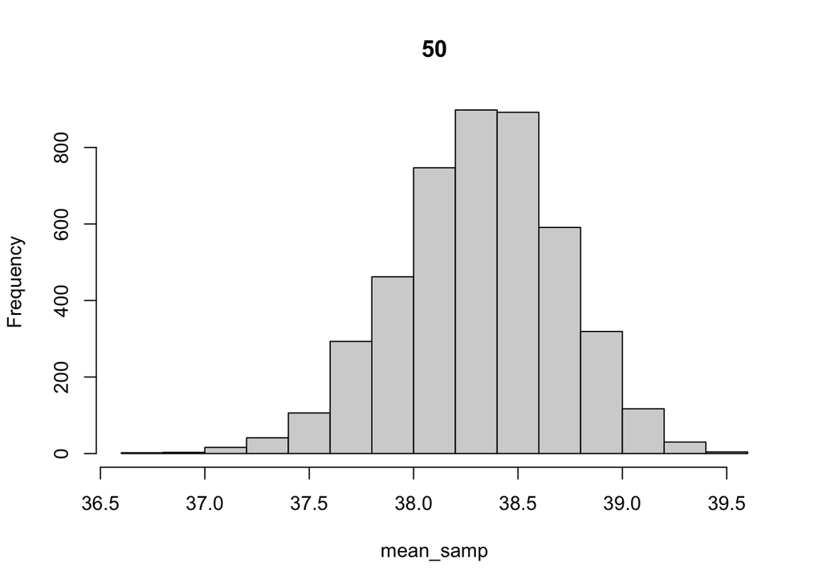

### Question 8

From the results in the previous section what can you conclude about the distribution of the sample mean, $\bar{x}$ and sample proportion, $\hat{p}$?

```r
#the distribution of the sample mean will always tend towards a guassian distribution with more samples
```

### Question 9

Comment on the center and spread of the distributions of the sample statistics based on the histograms in Question 5?

**Sample mean:**

```r
#The sample mean will tend towards the mean of the population with higher n.
```

**Sample proportion:**

```r
#The spread will become more symmetric, less skewed with more samples.
```

### Conclusion

Thus, we saw that the Central Limit Theorem guarantees normality under one of two assumptions: normality or approx. normality with sufficient sample size. The distribution of the sample statistic is called the sampling distribution.

These concept are the key underlying concepts in inference when we will be testing a hypothesized value of the population mean or the population proportion based on the random sample or when we will be developing confidence interval for the population mean or the population proportion